# PENPAL — Novelty, Transience, and Resonance (window-level, turn-agnostic)

PENPAL Collaboration Team

2026-08-08

## 1. Overview & Setup

Surprisal-based **Novelty**, **Transience** and **Resonance** across HH, H-LLM and LLM-LLM, computed on fixed word windows of the completed story with **no turn structure**.

Two things differ from the EMNLP analysis and govern how everything below must be read:

1. **The unit is a sub-turn window, not a turn.** At `w = 14` words (mean turn length in the source corpus is 26–28), a window sits mostly *inside* one author’s contribution, and the “next window” is usually the same author continuing. Transience here therefore measures **local continuation**, not **uptake by a partner**. It is not the same construct as EMNLP’s transience, and the innovation-bias slope is not comparable to EMNLP’s turn-level number.
2. **The estimand must be within-story.** EMNLP modelled turns nested in stories (a within-story process). A story-level regression answers a different, between-story question and is reported here only as a diagnostic (§6).

```r
root_dir <- if (basename(getwd()) == "analysis") ".." else "."

measures_path <- file.path(root_dir, "data", "processed", "surprisal", "penpal_measures_all.csv")
window_path   <- file.path(root_dir, "data", "processed", "surprisal", "surprisal_window_level.csv")
ann_path      <- file.path(root_dir, "data", "interim", "annotations", "penpal_annotations_final.csv")

condition_levels <- c("HH", "H-LLM", "LLM-LLM")

df_story <- read_csv(measures_path, show_col_types = FALSE) %>%
  mutate(cond = factor(cond, levels = condition_levels),
         llm  = as.numeric(cond) - 1)

df_ann <- if (file.exists(ann_path)) read_csv(ann_path, show_col_types = FALSE) else NULL

# The window file is REQUIRED for the primary model. Fail loudly rather than
# letting a downstream `if (!is.null(df_window))` silently skip the analysis --
# that is exactly how the mixed model went missing from earlier runs.
has_window <- file.exists(window_path)
if (!has_window) {
  warning(
    "MISSING: ", window_path, "\n",
    "The window-level mixed model (Section 5) is the primary analysis and cannot run.\n",
    "Regenerate it with:\n",
    "  python scripts/03_compute_surprisal_metrics.py --model google/gemma-4-31b --window 14\n",
    call. = FALSE
  )
}

df_window <- if (has_window) {
  read_csv(window_path, show_col_types = FALSE) %>%
    mutate(cond = factor(cond, levels = condition_levels))
} else NULL

cat("Story-level rows :", nrow(df_story), "\n")
```

```
## Story-level rows : 212
```

```r
cat("Window-level rows:", if (is.null(df_window)) "MISSING" else nrow(df_window), "\n")
```

```
## Window-level rows: 7907
```

```r
if (!is.null(df_window)) {
  cat("Windows per story: mean",
      round(mean(table(df_window$id)), 1),
      "| range", paste(range(table(df_window$id)), collapse = "-"), "\n")
}
```

```
## Windows per story: mean 37.3 | range 28-63
```

## 2. Human Evaluations & Inter-Annotator Reliability

```r
dims <- c("consistency", "coherence", "originality", "surprisingness", "enjoyment", "quality")
out_cols <- c(dims, "overall")

# The measures table now covers the FULL corpus, including stories nobody has
# rated. Report both n's so the ratings are not read as covering all stories.
df_story %>%
  group_by(cond) %>%
  summarise(n_stories = n(),
            n_rated = sum(!is.na(overall)),
            across(all_of(intersect(out_cols, colnames(df_story))),
                   ~ round(mean(.x, na.rm = TRUE), 2))) %>%
  kable(caption = "Mean human ratings by condition (means over rated stories only)")
```

Mean human ratings by condition (means over rated stories only)

| cond | n_stories | n_rated | consistency | coherence | originality | surprisingness | enjoyment | quality | overall |
| --- | --- | --- | --- | --- | --- | --- | --- | --- | --- |
| HH | 36 | 36 | 3.19 | 3.25 | 4.29 | 2.64 | 3.75 | 3.12 | 3.38 |
| H-LLM | 96 | 91 | 3.79 | 4.18 | 3.31 | 3.97 | 3.27 | 3.81 | 3.72 |
| LLM-LLM | 80 | 20 | 4.75 | 4.70 | 2.55 | 4.50 | 2.98 | 4.58 | 4.01 |

```r
pairs <- list(c("H-LLM", "HH"), c("H-LLM", "LLM-LLM"), c("HH", "LLM-LLM"))

map_dfr(pairs, function(pair) {
  a <- pair[1]; b <- pair[2]
  p_vals <- map_dbl(dims, function(m) {
    va <- df_story %>% filter(cond == a) %>% pull(m) %>% na.omit()
    vb <- df_story %>% filter(cond == b) %>% pull(m) %>% na.omit()
    wilcox.test(va, vb)$p.value
  })
  tibble(Dimension = dims, Contrast = paste(a, "vs", b),
         p_value = p_vals, q_FDR = p.adjust(p_vals, method = "BH"))
}) %>%
  mutate(across(c(p_value, q_FDR), ~ round(.x, 4))) %>%
  kable(caption = "Mann-Whitney contrasts on human ratings (BH-FDR within contrast)")
```

Mann-Whitney contrasts on human ratings (BH-FDR within contrast)

| Dimension | Contrast | p_value | q_FDR |
| --- | --- | --- | --- |
| consistency | H-LLM vs HH | 0.0007 | 0.0008 |
| coherence | H-LLM vs HH | 0.0000 | 0.0000 |
| originality | H-LLM vs HH | 0.0000 | 0.0000 |
| surprisingness | H-LLM vs HH | 0.0000 | 0.0000 |
| enjoyment | H-LLM vs HH | 0.0179 | 0.0179 |
| quality | H-LLM vs HH | 0.0002 | 0.0003 |
| consistency | H-LLM vs LLM-LLM | 0.0000 | 0.0000 |
| coherence | H-LLM vs LLM-LLM | 0.0027 | 0.0054 |
| originality | H-LLM vs LLM-LLM | 0.0091 | 0.0121 |
| surprisingness | H-LLM vs LLM-LLM | 0.0101 | 0.0121 |
| enjoyment | H-LLM vs LLM-LLM | 0.3416 | 0.3416 |
| quality | H-LLM vs LLM-LLM | 0.0001 | 0.0002 |
| consistency | HH vs LLM-LLM | 0.0000 | 0.0000 |
| coherence | HH vs LLM-LLM | 0.0000 | 0.0000 |
| originality | HH vs LLM-LLM | 0.0000 | 0.0000 |
| surprisingness | HH vs LLM-LLM | 0.0000 | 0.0000 |
| enjoyment | HH vs LLM-LLM | 0.0532 | 0.0532 |
| quality | HH vs LLM-LLM | 0.0000 | 0.0000 |

### Reliability, pooled **and within condition**

Pooled reliability is inflated by between-condition variance: two annotators who merely agree that HH stories are more original than LLM-LLM ones will show a respectable pooled rho without agreeing about any individual story. The within-condition columns are the honest ones. Absolute agreement is reported alongside rho because correlation is depressed by range restriction, which bites hard in LLM-LLM where several dimensions sit at ceiling.

```r
# The annotation file is WIDE: one row per story with ann1_* / ann2_* columns
# (there is no annotation_id / long format any more).
raw_dims <- c(
  consistency    = "coherence_element_consistency",
  coherence      = "coherence_logical_progression",
  originality    = "creativity_originality",
  surprisingness = "creativity_surprisingness",
  enjoyment      = "likeability_enjoyability",
  quality        = "likeability_quality"
)

if (!is.null(df_ann) && all(paste0("ann1_", raw_dims) %in% colnames(df_ann))) {

  ann_cond <- df_ann %>%
    mutate(cond = factor(recode(tolower(condition),
                                hh = "HH", ha = "H-LLM", aa = "LLM-LLM"),
                         levels = condition_levels))

  pick <- function(cond_filter = NULL) {
    map_dfr(names(raw_dims), function(d) {
      a <- suppressWarnings(as.numeric(ann_cond[[paste0("ann1_", raw_dims[[d]])]]))
      b <- suppressWarnings(as.numeric(ann_cond[[paste0("ann2_", raw_dims[[d]])]]))
      keep <- !is.na(a) & !is.na(b)
      if (!is.null(cond_filter)) keep <- keep & ann_cond$cond == cond_filter
      if (sum(keep) < 3) {
        return(tibble(Dimension = d, rho = NA_real_, mad = NA_real_, n = sum(keep)))
      }
      tibble(Dimension = d,
             rho = suppressWarnings(cor(a[keep], b[keep], method = "spearman")),
             mad = mean(abs(a[keep] - b[keep])),
             n   = sum(keep))
    })
  }

  rel_tbl <- pick() %>%
    select(Dimension, rho_pooled = rho, mad_pooled = mad, n_pooled = n) %>%
    left_join(pick("HH")      %>% select(Dimension, rho_HH = rho, mad_HH = mad), by = "Dimension") %>%
    left_join(pick("H-LLM")   %>% select(Dimension, rho_HLLM = rho, mad_HLLM = mad), by = "Dimension") %>%
    left_join(pick("LLM-LLM") %>% select(Dimension, rho_AA = rho, mad_AA = mad), by = "Dimension") %>%
    mutate(across(where(is.numeric), ~ round(.x, 3)))

  kable(rel_tbl,
        caption = paste("Inter-annotator reliability, pooled vs within condition.",
                        "rho = Spearman; mad = mean |ann1 - ann2| on the 5-point scale.",
                        "Pooled rho is inflated by between-condition variance;",
                        "mad is robust to the ceiling effects in LLM-LLM."))
} else {
  message("Annotation file does not have the expected ann1_/ann2_ columns; skipping reliability.")
}
```

Inter-annotator reliability, pooled vs within condition. rho = Spearman; mad = mean |ann1 - ann2| on the 5-point scale. Pooled rho is inflated by between-condition variance; mad is robust to the ceiling effects in LLM-LLM.

| Dimension | rho_pooled | mad_pooled | n_pooled | rho_HH | mad_HH | rho_HLLM | mad_HLLM | rho_AA | mad_AA |
| --- | --- | --- | --- | --- | --- | --- | --- | --- | --- |
| consistency | 0.212 | 1.276 | 145 | 0.125 | 1.889 | 0.151 | 1.225 | 0.015 | 0.40 |
| coherence | 0.282 | 0.972 | 144 | 0.316 | 1.333 | 0.162 | 0.932 | -0.091 | 0.50 |
| originality | 0.452 | 1.110 | 145 | 0.356 | 0.694 | 0.384 | 1.169 | 0.183 | 1.60 |
| surprisingness | 0.419 | 1.014 | 144 | 0.469 | 1.086 | 0.256 | 1.079 | 0.148 | 0.60 |
| enjoyment | 0.429 | 1.125 | 144 | 0.426 | 0.914 | 0.332 | 1.180 | 0.472 | 1.25 |
| quality | 0.359 | 0.931 | 145 | 0.187 | 1.250 | 0.285 | 0.888 | 0.361 | 0.55 |

## 3. NTR descriptives by condition

```r
surp_cols <- c("s_novelty", "s_transience", "s_resonance")

df_story %>%
  group_by(cond) %>%
  summarise(n = n(),
            across(all_of(surp_cols),
                   list(mean = ~ round(mean(.x, na.rm = TRUE), 3),
                        sd   = ~ round(sd(.x, na.rm = TRUE), 3)),
                   .names = "{.col}_{.fn}")) %>%
  kable(caption = "Surprisal NTR by condition (bits). Less negative = more novel / more transient.")
```

Surprisal NTR by condition (bits). Less negative = more novel / more transient.

| cond | n | s_novelty_mean | s_novelty_sd | s_transience_mean | s_transience_sd | s_resonance_mean | s_resonance_sd |
| --- | --- | --- | --- | --- | --- | --- | --- |
| HH | 36 | -2.914 | 0.273 | -1.758 | 0.219 | -1.156 | 0.308 |
| H-LLM | 96 | -3.303 | 0.262 | -1.996 | 0.179 | -1.307 | 0.251 |
| LLM-LLM | 80 | -4.072 | 0.210 | -2.701 | 0.226 | -1.371 | 0.181 |

## 4. Trend with model involvement (RQ1)

The simple ordinal trend across HH < H-LLM < LLM-LLM. This is the most robust result in the surprisal family and is reported independently of any slope model.

```r
map_dfr(surp_cols, function(m) {
  ct <- suppressWarnings(cor.test(df_story$llm, df_story[[m]],
                                  method = "spearman", exact = FALSE))
  kw <- kruskal.test(df_story[[m]] ~ df_story$cond)
  tibble(Metric = m,
         rho_LLMness = round(unname(ct$estimate), 3),
         p_trend = signif(ct$p.value, 3),
         KW_chisq = round(unname(kw$statistic), 2),
         p_KW = signif(kw$p.value, 3))
}) %>%
  mutate(q_FDR = signif(p.adjust(p_trend, method = "BH"), 3)) %>%
  kable(caption = "Monotone trend with model involvement (Spearman on ordinal condition) + Kruskal-Wallis")
```

Monotone trend with model involvement (Spearman on ordinal condition) + Kruskal-Wallis

| Metric | rho_LLMness | p_trend | KW_chisq | p_KW | q_FDR |
| --- | --- | --- | --- | --- | --- |
| s_novelty | -0.863 | 0.000000 | 159.07 | 0.00000 | 0.000000 |
| s_transience | -0.860 | 0.000000 | 158.79 | 0.00000 | 0.000000 |
| s_resonance | -0.235 | 0.000574 | 12.87 | 0.00161 | 0.000574 |

```r
map_dfr(pairs, function(pair) {
  a <- pair[1]; b <- pair[2]
  p_vals <- map_dbl(surp_cols, function(m) {
    va <- df_story %>% filter(cond == a) %>% pull(m) %>% na.omit()
    vb <- df_story %>% filter(cond == b) %>% pull(m) %>% na.omit()
    wilcox.test(va, vb)$p.value
  })
  tibble(Metric = surp_cols, Contrast = paste(a, "vs", b),
         p_value = signif(p_vals, 3),
         q_FDR = signif(p.adjust(p_vals, method = "BH"), 3))
}) %>%
  kable(caption = "Pairwise condition contrasts on NTR (BH-FDR within contrast)")
```

Pairwise condition contrasts on NTR (BH-FDR within contrast)

| Metric | Contrast | p_value | q_FDR |
| --- | --- | --- | --- |
| s_novelty | H-LLM vs HH | 0.000000 | 0.000000 |
| s_transience | H-LLM vs HH | 0.000000 | 0.000000 |
| s_resonance | H-LLM vs HH | 0.014300 | 0.014300 |
| s_novelty | H-LLM vs LLM-LLM | 0.000000 | 0.000000 |
| s_transience | H-LLM vs LLM-LLM | 0.000000 | 0.000000 |
| s_resonance | H-LLM vs LLM-LLM | 0.101000 | 0.101000 |
| s_novelty | HH vs LLM-LLM | 0.000000 | 0.000000 |
| s_transience | HH vs LLM-LLM | 0.000000 | 0.000000 |
| s_resonance | HH vs LLM-LLM | 0.000407 | 0.000407 |

## 5. Innovation bias — window-level mixed models (primary)

### 5.1 Why the predictor must be decomposed

`s_resonance` is by construction `s_novelty - s_transience`. Regressing resonance on novelty therefore has the predictor inside the outcome, and the slope is an exact reparameterisation:

$$\beta_{\text{res}\sim\text{nov}} \;=\; 1
- \beta_{\text{tra}\sim\text{nov}}$$

So “innovation bias > 1” is *identically* the statement “more novel windows have **lower** (more negative) transience”, i.e. stronger forward binding. Both parameterisations are reported; the transience model is the transparent one.

A raw `s_novelty` predictor also confounds two different comparisons: differences *between* stories (some stories are globally less predictable) and variation *within* a story (this window is more surprising than that story’s norm). EMNLP estimated the within-story process. We therefore split novelty into a story-mean (between) and a story-centred deviation (within).

```r
df_win <- df_window %>%
  filter(!is.na(s_resonance), !is.na(s_novelty), !is.na(s_transience), !is.na(cond)) %>%
  group_by(id) %>%
  mutate(nov_story_mean = mean(s_novelty, na.rm = TRUE),
         nov_within     = s_novelty - nov_story_mean) %>%
  ungroup() %>%
  mutate(nov_story_mean_c = as.numeric(scale(nov_story_mean, scale = FALSE)))

cat("Windows:", nrow(df_win), "in", n_distinct(df_win$id), "stories\n")
```

```
## Windows: 7483 in 212 stories
```

```r
cat("Within-story SD of novelty:", round(sd(df_win$nov_within), 3),
    "| between-story SD:", round(sd(df_win$nov_story_mean), 3), "\n")
```

```
## Within-story SD of novelty: 0.803 | between-story SD: 0.511
```

### 5.2 Primary model — transience on within-story novelty

```r
m_tra <- lmer(
  s_transience ~ nov_within * cond + nov_story_mean_c + (1 + nov_within | id),
  data = df_win,
  control = lmerControl(optimizer = "bobyqa", optCtrl = list(maxfun = 2e5))
)

# Fall back to a random intercept if the random-slope model is singular.
if (isSingular(m_tra, tol = 1e-4)) {
  message("Random-slope model singular; refitting with random intercept only.")
  m_tra <- lmer(
    s_transience ~ nov_within * cond + nov_story_mean_c + (1 | id),
    data = df_win,
    control = lmerControl(optimizer = "bobyqa", optCtrl = list(maxfun = 2e5))
  )
}

summary(m_tra)
```

```
## Linear mixed model fit by REML. t-tests use Satterthwaite's method [
## lmerModLmerTest]
## Formula:
## s_transience ~ nov_within * cond + nov_story_mean_c + (1 + nov_within |
##     id)
##    Data: df_win
## Control: lmerControl(optimizer = "bobyqa", optCtrl = list(maxfun = 2e+05))
##
## REML criterion at convergence: 18908.6
##
## Scaled residuals:
##      Min       1Q   Median       3Q      Max
## -15.2783  -0.5066   0.0750   0.6052   3.1940
##
## Random effects:
##  Groups   Name        Variance Std.Dev. Corr
##  id       (Intercept) 0.013658 0.11687
##           nov_within  0.006535 0.08084  -0.19
##  Residual             0.715401 0.84581
## Number of obs: 7483, groups:  id, 212
##
## Fixed effects:
##                          Estimate Std. Error         df t value Pr(>|t|)
## (Intercept)             -2.004673   0.045065 209.043599 -44.484  < 2e-16 ***
## nov_within              -0.008738   0.034832 249.598178  -0.251   0.8021
## condH-LLM               -0.086803   0.041563 216.473988  -2.088   0.0379 *
## condLLM-LLM             -0.494830   0.070179 205.472312  -7.051 2.65e-11 ***
## nov_story_mean_c         0.387077   0.051891 209.273098   7.459 2.28e-12 ***
## nov_within:condH-LLM     0.029023   0.039715 219.784301   0.731   0.4657
## nov_within:condLLM-LLM   0.082567   0.041658 243.153408   1.982   0.0486 *
## ---
## Signif. codes:  0 '***' 0.001 '**' 0.01 '*' 0.05 '.' 0.1 ' ' 1
##
## Correlation of Fixed Effects:
##             (Intr) nv_wth cH-LLM cLLM-L nv_s__ n_:H-L
## nov_within  -0.032
## condH-LLM   -0.861  0.035
## condLLM-LLM -0.922  0.021  0.741
## nv_stry_mn_ -0.735  0.001  0.493  0.853
## nv_wt:H-LLM  0.027 -0.877 -0.041 -0.017  0.001
## nv_:LLM-LLM  0.027 -0.836 -0.029 -0.025 -0.001  0.733
```

```r
anova(m_tra)
```

```
## Type III Analysis of Variance Table with Satterthwaite's method
##                  Sum Sq Mean Sq NumDF  DenDF F value    Pr(>F)
## nov_within        2.484   2.484     1 222.06  3.4718   0.06374 .
## cond             51.159  25.579     2 209.52 35.7552 4.367e-14 ***
## nov_story_mean_c 39.807  39.807     1 209.27 55.6433 2.281e-12 ***
## nov_within:cond   3.619   1.809     2 211.11  2.5291   0.08215 .
## ---
## Signif. codes:  0 '***' 0.001 '**' 0.01 '*' 0.05 '.' 0.1 ' ' 1
```

### 5.3 Same model in the resonance parameterisation

Identical fit, rescaled; included so the slopes are directly comparable to how EMNLP reported them.

```r
m_res <- update(m_tra, s_resonance ~ .)
summary(m_res)
```

```
## Linear mixed model fit by REML. t-tests use Satterthwaite's method [
## lmerModLmerTest]
## Formula:
## s_resonance ~ nov_within + cond + nov_story_mean_c + (1 + nov_within |
##     id) + nov_within:cond
##    Data: df_win
## Control: lmerControl(optimizer = "bobyqa", optCtrl = list(maxfun = 2e+05))
##
## REML criterion at convergence: 18908.6
##
## Scaled residuals:
##     Min      1Q  Median      3Q     Max
## -3.1940 -0.6052 -0.0750  0.5066 15.2783
##
## Random effects:
##  Groups   Name        Variance Std.Dev. Corr
##  id       (Intercept) 0.013658 0.11687
##           nov_within  0.006535 0.08084  -0.19
##  Residual             0.715401 0.84581
## Number of obs: 7483, groups:  id, 212
##
## Fixed effects:
##                         Estimate Std. Error        df t value Pr(>|t|)
## (Intercept)             -1.54601    0.04507 209.04360 -34.306  < 2e-16 ***
## nov_within               1.00874    0.03483 249.59820  28.960  < 2e-16 ***
## condH-LLM                0.08680    0.04156 216.47399   2.088   0.0379 *
## condLLM-LLM              0.49483    0.07018 205.47232   7.051 2.65e-11 ***
## nov_story_mean_c         0.61292    0.05189 209.27310  11.812  < 2e-16 ***
## nov_within:condH-LLM    -0.02902    0.03972 219.78432  -0.731   0.4657
## nov_within:condLLM-LLM  -0.08257    0.04166 243.15343  -1.982   0.0486 *
## ---
## Signif. codes:  0 '***' 0.001 '**' 0.01 '*' 0.05 '.' 0.1 ' ' 1
##
## Correlation of Fixed Effects:
##             (Intr) nv_wth cH-LLM cLLM-L nv_s__ n_:H-L
## nov_within  -0.032
## condH-LLM   -0.861  0.035
## condLLM-LLM -0.922  0.021  0.741
## nv_stry_mn_ -0.735  0.001  0.493  0.853
## nv_wt:H-LLM  0.027 -0.877 -0.041 -0.017  0.001
## nv_:LLM-LLM  0.027 -0.836 -0.029 -0.025 -0.001  0.733
```

### 5.4 Per-condition slopes

```r
if (requireNamespace("emmeans", quietly = TRUE)) {
  library(emmeans)
  emm_options(lmerTest.limit = 10000, pbkrtest.limit = 10000)
  tr_slopes  <- emtrends(m_tra, ~ cond, var = "nov_within")
  res_slopes <- emtrends(m_res, ~ cond, var = "nov_within")

  as.data.frame(tr_slopes) %>%
    rename(any_of(c(lower.CL = "asymp.LCL", upper.CL = "asymp.UCL"))) %>%
    select(cond, transience_slope = nov_within.trend, SE, lower.CL, upper.CL) %>%
    left_join(as.data.frame(res_slopes) %>%
                rename(any_of(c(lower.CL = "asymp.LCL", upper.CL = "asymp.UCL"))) %>%
                select(cond, resonance_slope = nov_within.trend), by = "cond") %>%
    mutate(check_1_minus = round(1 - transience_slope, 3),
           across(where(is.numeric), ~ round(.x, 3))) %>%
    kable(caption = "Within-story slopes by condition. resonance_slope should equal 1 - transience_slope.")

  cat("\nPairwise contrasts of the within-story novelty slope:\n")
  print(pairs(tr_slopes, adjust = "BH"))
} else {
  message("Install `emmeans` for per-condition slopes.")
}
```

[output not shown]

```
##
## Pairwise contrasts of the within-story novelty slope:
##  contrast            estimate     SE  df t.ratio p.value
##  HH - (H-LLM)         -0.0290 0.0398 228  -0.730  0.4661
##  HH - (LLM-LLM)       -0.0826 0.0417 252  -1.981  0.1108
##  (H-LLM) - (LLM-LLM)  -0.0535 0.0298 198  -1.797  0.1108
##
## Degrees-of-freedom method: kenward-roger
## P value adjustment: BH method for 3 tests
```

## 6. Diagnostic: why the story-level model is NOT reported

The previous version of this document fitted `lm(s_resonance ~ s_novelty * cond)` on 147 story means. That model is retained here **only** to show why it cannot be interpreted as innovation bias.

At story level the slope is again `1 - beta(transience ~ novelty)`, and between stories novelty and transience are strongly *positively* coupled: both are built from the same contextual-surprisal term, and both mostly track a single nuisance dimension — how predictable the story is to the LM overall. Because that coupling is positive, every story-level slope is forced below 1. And because the coupling is *strongest* in the most stylistically homogeneous condition, the slope ordering simply inverts within-condition homogeneity. It carries no information about narrative uptake.

```r
diag_tbl <- df_story %>%
  filter(!is.na(s_novelty), !is.na(s_transience), !is.na(s_resonance)) %>%
  group_by(cond) %>%
  summarise(
    n              = n(),
    slope_res_nov  = round(coef(lm(s_resonance  ~ s_novelty))[2], 3),
    slope_tra_nov  = round(coef(lm(s_transience ~ s_novelty))[2], 3),
    one_minus_tra  = round(1 - coef(lm(s_transience ~ s_novelty))[2], 3),
    r_nov_tra      = round(cor(s_novelty, s_transience), 3),
    sd_novelty     = round(sd(s_novelty), 3),
    .groups = "drop"
  )
kable(diag_tbl,
      caption = "Story-level (BETWEEN-story) slopes. slope_res_nov tracks 1 - slope_tra_nov; the ordering follows r(nov,tra), i.e. within-condition homogeneity, not uptake.")
```

Story-level (BETWEEN-story) slopes. slope_res_nov tracks 1 - slope_tra_nov; the ordering follows r(nov,tra), i.e. within-condition homogeneity, not uptake.

| cond | n | slope_res_nov | slope_tra_nov | one_minus_tra | r_nov_tra | sd_novelty |
| --- | --- | --- | --- | --- | --- | --- |
| HH | 36 | 0.817 | 0.183 | 0.817 | 0.228 | 0.273 |
| H-LLM | 96 | 0.724 | 0.276 | 0.724 | 0.404 | 0.262 |
| LLM-LLM | 80 | 0.292 | 0.708 | 0.292 | 0.658 | 0.210 |

```r
gap <- with(df_story, abs(s_resonance - (s_novelty - s_transience)))
cat("Identity check  max |s_resonance - (s_novelty - s_transience)| =",
    round(max(gap, na.rm = TRUE), 4), "\n")
```

```
## Identity check  max |s_resonance - (s_novelty - s_transience)| = 0
```

```r
cat("If this exceeds ~1e-6, the three story means were averaged over different\n",
    "window index ranges -- regenerate with the fixed scripts/03_compute_surprisal_metrics.py\n")
```

```
## If this exceeds ~1e-6, the three story means were averaged over different
##  window index ranges -- regenerate with the fixed scripts/03_compute_surprisal_metrics.py
```

## 7. Correlations with human judgments

Reported for the three NTR measures and the stylometric block, with FDR across all tested pairs. Treat as exploratory: the confirmatory claims are the condition trends in §4.

```r
style_cols <- c("n_words", "n_sentences", "mean_word_length", "mean_sentence_length",
                "ttr", "hapax_ratio", "comma_density", "flesch_approx",
                "adjacent_sentence_similarity", "semantic_distinctiveness")
existing_meas <- intersect(c(style_cols, surp_cols), colnames(df_story))

corr_long <- expand_grid(Metric = existing_meas, Rating = dims) %>%
  mutate(res = map2(Metric, Rating, function(m, d) {
    v <- df_story[[m]]; r <- df_story[[d]]
    ok <- !is.na(v) & !is.na(r)
    if (sum(ok) < 6) return(tibble(rho = NA_real_, p = NA_real_))
    ct <- suppressWarnings(cor.test(v[ok], r[ok], method = "spearman", exact = FALSE))
    tibble(rho = unname(ct$estimate), p = ct$p.value)
  })) %>%
  unnest(res) %>%
  mutate(q_FDR = p.adjust(p, method = "BH"))

corr_long %>%
  select(Metric, Rating, rho) %>%
  pivot_wider(names_from = Rating, values_from = rho) %>%
  mutate(across(-Metric, ~ round(.x, 2))) %>%
  kable(caption = "Spearman rho: computational metrics x human ratings")
```

Spearman rho: computational metrics x human ratings

| Metric | consistency | coherence | originality | surprisingness | enjoyment | quality |
| --- | --- | --- | --- | --- | --- | --- |
| n_words | 0.13 | 0.01 | -0.01 | -0.01 | 0.06 | 0.12 |
| n_sentences | -0.24 | -0.21 | 0.29 | -0.24 | 0.25 | -0.14 |
| mean_word_length | 0.40 | 0.30 | -0.12 | 0.32 | -0.01 | 0.36 |
| mean_sentence_length | 0.30 | 0.22 | -0.32 | 0.26 | -0.26 | 0.20 |
| ttr | 0.14 | 0.14 | -0.11 | 0.23 | 0.08 | 0.17 |
| hapax_ratio | 0.14 | 0.14 | -0.14 | 0.23 | 0.04 | 0.18 |
| comma_density | 0.28 | 0.28 | -0.42 | 0.28 | -0.23 | 0.27 |
| flesch_approx | -0.38 | -0.22 | 0.23 | -0.28 | 0.13 | -0.29 |
| adjacent_sentence_similarity | 0.01 | -0.03 | -0.07 | -0.07 | -0.24 | -0.07 |
| semantic_distinctiveness | -0.10 | -0.11 | 0.27 | -0.05 | 0.26 | -0.15 |
| s_novelty | -0.40 | -0.35 | 0.31 | -0.35 | 0.04 | -0.41 |
| s_transience | -0.41 | -0.43 | 0.33 | -0.44 | 0.11 | -0.36 |
| s_resonance | -0.10 | -0.04 | 0.06 | -0.05 | -0.08 | -0.18 |

```r
corr_long %>%
  filter(!is.na(q_FDR), q_FDR < .05) %>%
  arrange(q_FDR) %>%
  mutate(rho = round(rho, 3), q_FDR = signif(q_FDR, 3)) %>%
  select(Metric, Rating, rho, q_FDR) %>%
  kable(caption = "Surviving FDR < .05")
```

Surviving FDR < .05

| Metric | Rating | rho | q_FDR |
| --- | --- | --- | --- |
| s_transience | surprisingness | -0.439 | 2.00e-06 |
| s_transience | coherence | -0.428 | 2.50e-06 |
| comma_density | originality | -0.415 | 3.60e-06 |
| s_novelty | quality | -0.412 | 3.60e-06 |
| s_transience | consistency | -0.411 | 3.60e-06 |
| mean_word_length | consistency | 0.402 | 6.00e-06 |
| s_novelty | consistency | -0.395 | 8.20e-06 |
| flesch_approx | consistency | -0.383 | 1.64e-05 |
| s_transience | quality | -0.363 | 5.34e-05 |
| mean_word_length | quality | 0.356 | 7.36e-05 |
| s_novelty | surprisingness | -0.354 | 7.50e-05 |
| s_novelty | coherence | -0.352 | 8.04e-05 |
| s_transience | originality | 0.331 | 2.51e-04 |
| mean_sentence_length | originality | -0.320 | 4.44e-04 |
| mean_word_length | surprisingness | 0.318 | 4.50e-04 |
| s_novelty | originality | 0.314 | 5.35e-04 |
| mean_sentence_length | consistency | 0.299 | 1.09e-03 |
| mean_word_length | coherence | 0.296 | 1.20e-03 |
| n_sentences | originality | 0.293 | 1.32e-03 |
| flesch_approx | quality | -0.286 | 1.70e-03 |
| flesch_approx | surprisingness | -0.284 | 1.81e-03 |
| comma_density | coherence | 0.280 | 2.13e-03 |
| comma_density | surprisingness | 0.279 | 2.13e-03 |
| comma_density | consistency | 0.277 | 2.18e-03 |
| comma_density | quality | 0.273 | 2.51e-03 |
| semantic_distinctiveness | originality | 0.271 | 2.74e-03 |
| mean_sentence_length | surprisingness | 0.263 | 3.65e-03 |
| mean_sentence_length | enjoyment | -0.256 | 4.64e-03 |
| semantic_distinctiveness | enjoyment | 0.257 | 4.64e-03 |
| n_sentences | enjoyment | 0.254 | 4.99e-03 |
| adjacent_sentence_similarity | enjoyment | -0.243 | 7.58e-03 |
| n_sentences | consistency | -0.241 | 8.14e-03 |
| n_sentences | surprisingness | -0.238 | 8.78e-03 |
| ttr | surprisingness | 0.234 | 9.73e-03 |
| flesch_approx | originality | 0.235 | 9.73e-03 |
| hapax_ratio | surprisingness | 0.227 | 1.19e-02 |
| comma_density | enjoyment | -0.227 | 1.19e-02 |
| mean_sentence_length | coherence | 0.223 | 1.33e-02 |
| flesch_approx | coherence | -0.223 | 1.33e-02 |
| n_sentences | coherence | -0.208 | 2.26e-02 |
| mean_sentence_length | quality | 0.196 | 3.33e-02 |

## 8. Visualizations

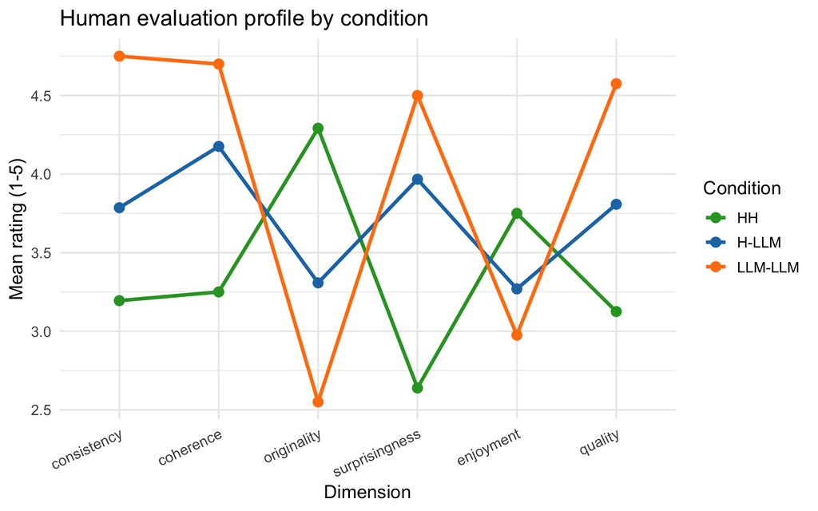

Human evaluation profile by condition

```r
df_story %>%
  pivot_longer(all_of(dims), names_to = "Dimension", values_to = "Rating") %>%
  mutate(Dimension = factor(Dimension, levels = dims)) %>%
  group_by(cond, Dimension) %>%
  summarise(Mean_Rating = mean(Rating, na.rm = TRUE), .groups = "drop") %>%
  ggplot(aes(Dimension, Mean_Rating, color = cond, group = cond)) +
  geom_line(linewidth = 1.2) + geom_point(size = 3) +
  scale_color_manual(values = condition_colors) +
  labs(y = "Mean rating (1-5)", color = "Condition",
       title = "Human evaluation profile by condition") +
  theme(axis.text.x = element_text(angle = 25, hjust = 1))
```

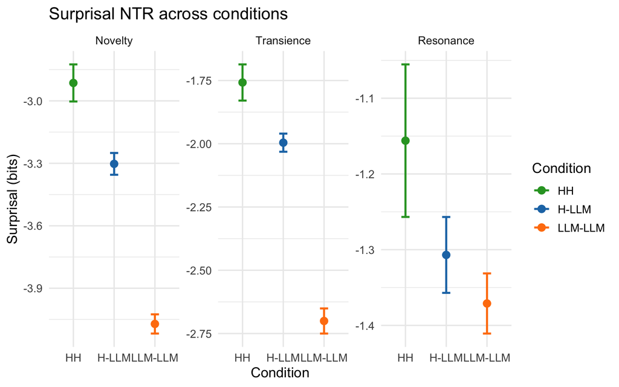

Surprisal NTR by condition

```r
df_story %>%
  pivot_longer(all_of(surp_cols), names_to = "Metric", values_to = "Value") %>%
  mutate(Metric = factor(Metric, levels = surp_cols,
                         labels = c("Novelty", "Transience", "Resonance"))) %>%
  group_by(cond, Metric) %>%
  summarise(Mean = mean(Value, na.rm = TRUE),
            SE = sd(Value, na.rm = TRUE) / sqrt(n()), .groups = "drop") %>%
  ggplot(aes(cond, Mean, color = cond)) +
  geom_point(size = 3) +
  geom_errorbar(aes(ymin = Mean - 1.96 * SE, ymax = Mean + 1.96 * SE),
                width = 0.2, linewidth = 0.9) +
  facet_wrap(~ Metric, scales = "free_y") +
  scale_color_manual(values = condition_colors) +
  labs(x = "Condition", y = "Surprisal (bits)", color = "Condition",
       title = "Surprisal NTR across conditions")
```

### Within-story innovation bias

Each thin line is one story’s own within-story relationship; thick lines are the condition-level fits. This is the estimand the mixed model targets — unlike a scatter of story means, which shows only between-story variation.

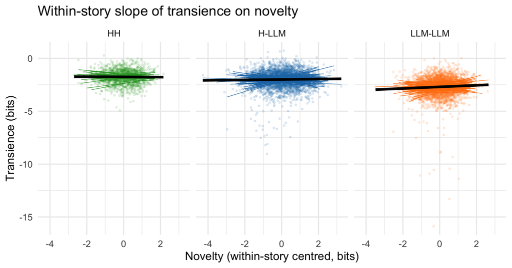

Within-story transience vs novelty

```r
ggplot(df_win, aes(nov_within, s_transience, color = cond)) +
  geom_point(alpha = 0.12, size = 0.7) +
  geom_smooth(aes(group = id), method = "lm", se = FALSE,
              linewidth = 0.25, alpha = 0.3) +
  geom_smooth(method = "lm", se = TRUE, linewidth = 1.4, color = "black") +
  facet_wrap(~ cond) +
  scale_color_manual(values = condition_colors, guide = "none") +
  labs(x = "Novelty (within-story centred, bits)", y = "Transience (bits)",
       title = "Within-story slope of transience on novelty")
```

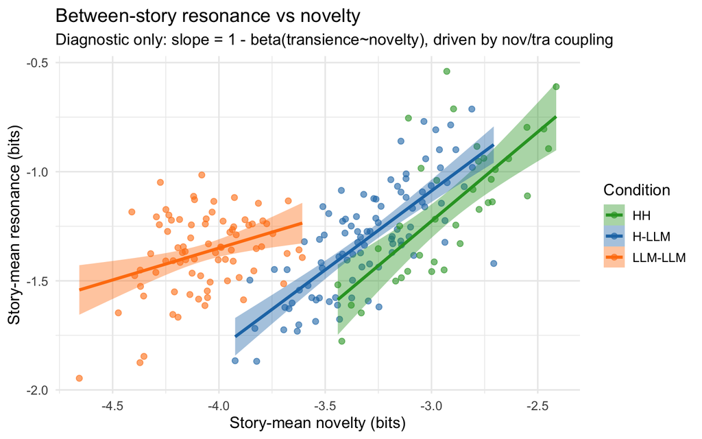

BETWEEN-story association (diagnostic only – not innovation bias)

```r
ggplot(df_story, aes(s_novelty, s_resonance, color = cond, fill = cond)) +
  geom_point(alpha = 0.6, size = 2) +
  geom_smooth(method = "lm", se = TRUE, linewidth = 1.2) +
  scale_color_manual(values = condition_colors) +
  scale_fill_manual(values = condition_colors) +
  labs(x = "Story-mean novelty (bits)", y = "Story-mean resonance (bits)",
       color = "Condition", fill = "Condition",
       title = "Between-story resonance vs novelty",
       subtitle = "Diagnostic only: slope = 1 - beta(transience~novelty), driven by nov/tra coupling")
```